# Data Project for R2

Brennan Nick

December 06, 2020

```r
library(tidyverse)
library(sf)
library(tigris)
library(leaflet)
library(censusapi)

Sys.setenv(CENSUS_KEY="c8aa67e4086b4b5ce3a8717f59faa9a28f611dab")

acs_vars_2019_1yr <-
  listCensusMetadata(
    name = "2019/acs/acs1",
    type = "variables"
  )
```

```r
census_race_labels <-
  c(
    "White Alone",
    "Black or African American",
    "American Indian and Alaska Native Alone",
    "Asian Alone",
    "Native Hawaiian and Other Pacific Islander Alone)",
    "Some Other Race Alone",
    "Two or More Races"
  )
```

```r
alameda_education_race <-
  1:7 %>%
  map_dfr(function(x){
    getCensus(
      name = "acs/acs1",
      vintage = 2019,
      region = "county:001",
      regionin = "state:06",
      vars = paste0("group(B15002",LETTERS[x],")")
    ) %>%
      dplyr::select(!c(GEO_ID,state,NAME) & !ends_with(c("EA","MA","M"))) %>%
      pivot_longer(
        ends_with("E"),
        names_to = "variable",
        values_to = "estimate"
      ) %>%
      left_join(
        acs_vars_2019_1yr %>%
          dplyr::select(name, label),
        by = c("variable" = "name")
      ) %>%
      dplyr::select(-variable) %>%
      separate(
        label,
        into = c(NA,NA,NA,"education"),
        sep = "!!"
      ) %>%
      filter(!is.na(education)) %>%
      mutate(race = census_race_labels[x])
  })
```

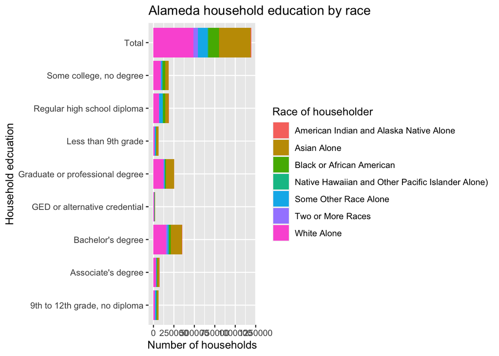

```r
alameda_education_race %>%
  group_by(education, race) %>%
  summarize(estimate = sum(estimate)) %>%
  rbind(
    alameda_education_race %>%
      filter(county == "001") %>%
      group_by(race) %>%
      summarize(estimate = sum(estimate)) %>%
      mutate(education = "Total")
  ) %>%
  ggplot() +
  geom_bar(
    aes(
      x = education %>% factor(),
      y = estimate,
      fill = race
    ),
    stat = "identity",
    position = "stack"
  ) +
  labs(
    x = "Household edcuation",
    y = "Number of households",
    title = "Alameda household education by race",
    fill = "Race of householder"
  ) +
  coord_flip()
```

*Above is a “Stacked” bar chart.

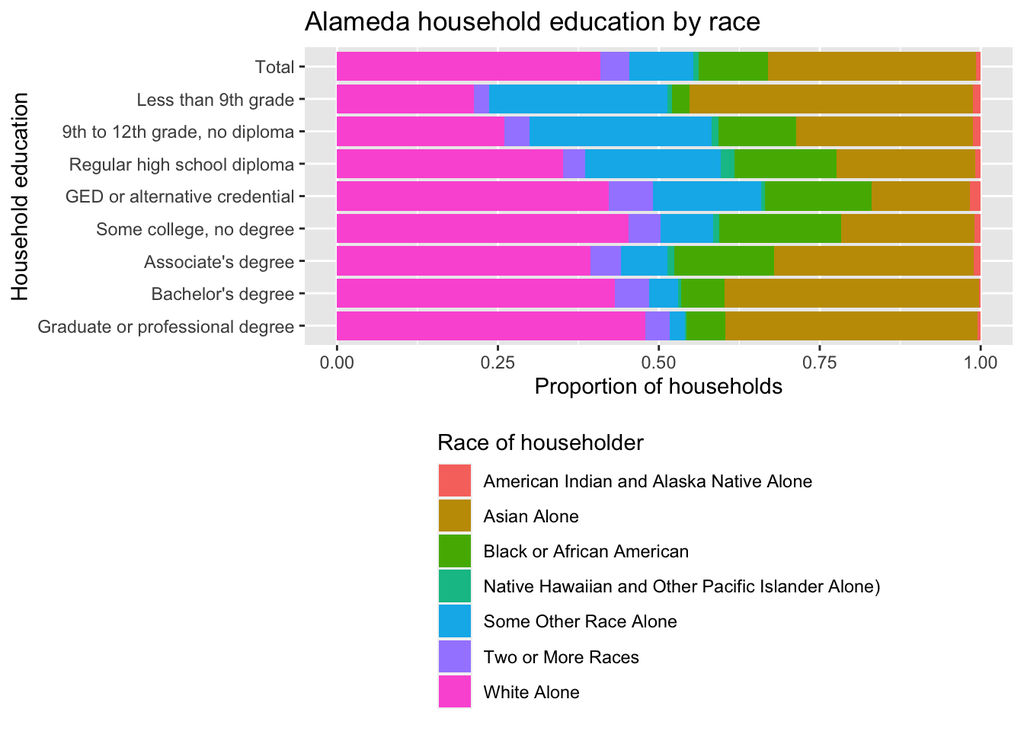

```r
graph<-
  alameda_education_race %>%
  group_by(education, race) %>%
  summarize(estimate = sum(estimate)) %>%
rbind(
 alameda_education_race %>%
    group_by(race) %>%
    summarize(estimate = sum(estimate)) %>%
    mutate(education = "Total")
)%>%
  ggplot() +
  geom_bar(
    aes(
      x = education %>%
        factor(levels = rev(c("Total", alameda_education_race$education[1:8]))),
      y = estimate,
      fill = race
    ),
    stat = "identity",
    position = "fill"
  ) +
  labs(
    x = "Household education",
    y = "Proportion of households",
    title = "Alameda household education by race",
    fill = "Race of householder"
  ) +
  coord_flip() +
  theme(
    legend.position = "bottom",
    legend.direction = "vertical"
  )
graph
```

*Above is a “Filled” bar chart.

In examining the “stacked” and “filled” bar charts of household education attainment in Alameda county by Race, it is apparant that there is disproportionate education attainment by race. The data only includes the members of the population who are 25 years and older, but the evidence is strong enough that, if younger members of the population were included, it would not alter the conclusions.

We see “White Alone” make up a disproportionately low proportion of those with less than a high school degree and a disproportionately high proportion of those with Graduate degrees.

Interestingly, we see “Black or African American” make up a very disproportionately low amount of those with an education “less than 9th grade”, an even lower proportion than “White Alone”. They then form a proportion moderately higher than their proportion of their population for the “middle” categories of “high school diploma,” “GED,” Some college, no degree," and “Associate’s degree.” They then make up a disproportionately low amount of those with Bachelor’s and Graduate’s degrees.

We then see “Asian” alone form a U-shape where they make up a disproportionately larger chunk of the lowest education levels, especially “Less than 9th grade;” a disproportionately smaller amount of the “middle” categories of “high school diploma,” “GED,” and “Some college, no degree;” and finaly, constituting a disproportionately high amount of those with Bachelor’s and Graduate degrees.

Taking it together, we see the greatest racial education disparity in the lower educational attainment of “Some other Race” and in the U-shaped nature of “Asian” educational attainment. All things considered, both “Whiet alone” and “Black or African American” never deviate incredibly far from their proportion of the population except for “White Alone’s” low proportion of those who do not finish high school. It should be worth noting, however, that the highest two education levels are, in fact, dominated by “White Alone” and “Asian,” with a very low proportion of Black/African American and Other.

```r
#temp <- tempfile()
#download.file("https://www2.census.gov/programs-surveys/acs/data/pums/2018/5-Year/csv_hca.zip",destfile = temp, mode = "wb")

#pums_hca_2018_5yr <- read_csv(unzip(temp,"psam_h06.csv"))

#unlink(temp)
```

```r
#install.packages("devtools")

#devtools::install_github("walkerke/tidycensus")
```

```r
library(tidycensus)

census_api_key("c8aa67e4086b4b5ce3a8717f59faa9a28f611dab")

pums_vars_2018 <-
  pums_variables %>%
  filter(year == 2018, survey == "acs5")

pums_vars_2018_distinct_hh <-
  pums_vars_2018 %>%
  distinct(var_code, var_label, data_type, level) %>%
  filter(level == "housing")
```

```r
#ca_pums <- get_pums(
#  variables = c(
#    "PUMA",
#    "AGEP",
#    "SCHG",
#    "ACCESS"
#  ),
#  state = "CA",
#  year = 2018,
#  survey = "acs5",
#  recode = T
#)
#saveRDS(ca_pums,"PUBLPOL 118X CA_PUMS.rds")

ca_pums <- readRDS("PUBLPOL 118X CA_PUMS.rds")
```

```r
alameda_county <- counties("CA", cb=TRUE, progress_bar=F) %>%
  filter(NAME=="Alameda")
library(mapview)

ca_pumas <-
  pumas("CA", cb = T, progress_bar = F)

alameda_pumas <-
  ca_pumas %>%
  st_centroid() %>%
  .[alameda_county, ] %>%
  st_set_geometry(NULL) %>%
  left_join(ca_pumas %>% select(GEOID10)) %>%
  st_as_sf()

alameda_pums <-
  ca_pums %>%
  filter(PUMA %in% alameda_pumas$PUMACE10)
```

```r
alameda_pums_internet <-
  alameda_pums %>%
  mutate(
    SCHG = SCHG %>% as.numeric(),
    k12 = ifelse(
      SCHG < 15,
      PWGTP,
      0
    ),
    k12_nointernet = ifelse(
      SCHG < 15 & ACCESS == "3",
      PWGTP,
      0
    )
  ) %>%
  group_by(PUMA) %>%
  summarize(
    perc_k12_nointernet =
      sum(k12_nointernet, na.rm = T)/sum(k12, na.rm = T)*100
  ) %>%
  left_join(
    alameda_pumas %>%
      select(PUMACE10),
    by = c("PUMA" = "PUMACE10")
  ) %>%
  st_as_sf()
pums_pal <- colorNumeric(
  palette = "Purples",
  domain = alameda_pums_internet$perc_k12_nointernet
)


leaflet() %>%
  addTiles() %>%
  addPolygons(
    data = alameda_pums_internet,
    fillColor = ~pums_pal(perc_k12_nointernet),
    color = "white",
    opacity = 0.5,
    fillOpacity = 0.5,
    weight = 1,
    label = ~paste0(
      round(perc_k12_nointernet),
      "% K-12 students without internet"
    ),
    highlightOptions = highlightOptions(
      weight = 2,
      opacity = 1
    )
  ) %>%
  addLegend(
    data = alameda_pums_internet,
    pal = pums_pal,
    values = ~perc_k12_nointernet,
    title = "% K-12 students without internet"
  )
```

[interactive chart not shown]

As seen in the map, most areas of Alameda county have a very low percent of K-12 students without internet. Most areas have only 2-5% without internet. There are only two localities which sharply deviate from this and they are in Oakland. The downtown Oakland locality reports 11% of K-12 students without internet and the East Oakland locality reports 18% of stduents without internet. These are some of the lowest income areas in Alameda county and are disproportionately African American in demographic composition.

As for using these data to understand the challenges of remote learning, these data are useful insofar as they show the percentage of K-12 students in each locality who simply do not even have the ability to go onto a remote call with the rest of the class. These data do not track any metrics of student performance before and after remote learning, student satisfaction, or information retention. Furthermore, these data also do not track any other impediments to at-home, remote learning such as having poor internet connection or a noisy home environment unconducive to learning.

```r
alameda_mobility_current_19 <-
  getCensus(
    name = "acs/acs1",
    vintage = 2019,
    region = "county:001",
    regionin = "state:06",
    vars = c("group(B07009)")
  ) %>%
  select(!c(GEO_ID,state,NAME) & !ends_with(c("EA","MA","M"))) %>%
  pivot_longer(
    ends_with("E"),
    names_to = "variable",
    values_to = "estimate"
  ) %>%
  left_join(
    acs_vars_2019_1yr %>%
      select(name, label),
    by = c("variable" = "name")
  ) %>%
  select(-variable) %>%
  separate(
    label,
    into = c(NA,NA,"mobility","education"),
    sep = "!!"
  ) %>%
  mutate(
    mobility = ifelse(
      mobility %in% c("Same house 1 year ago:", "Moved within same county:"),
      "Here since last year",
      "Inflow"
    )
  ) %>%
  filter(!is.na(education)) %>%
  group_by(mobility, education) %>%
  summarize(estimate = sum(estimate))
```

```r
alameda_mobility_lastyear_19 <-
  getCensus(
    name = "acs/acs1",
    vintage = 2019,
    region = "county:001",
    regionin = "state:06",
    vars = c("group(B07409)")
  ) %>%
  select(!c(GEO_ID,state,NAME) & !ends_with(c("EA","MA","M"))) %>%
  pivot_longer(
    ends_with("E"),
    names_to = "variable",
    values_to = "estimate"
  ) %>%
  left_join(
    acs_vars_2019_1yr %>%
      select(name, label),
    by = c("variable" = "name")
  ) %>%
  select(-variable) %>%
  separate(
    label,
    into = c(NA,NA,"mobility","education"),
    sep = "!!"
  ) %>%
  mutate(
    mobility = ifelse(
      mobility %in% c("Same house:", "Moved within same county:"),
      "Here since last year",
      "Outflow"
    )
  ) %>%
  filter(!is.na(education)) %>%
  group_by(mobility, education) %>%
  summarize(estimate = sum(estimate))
```

```r
alameda_mobility_current_18 <-
  getCensus(
    name = "acs/acs1",
    vintage = 2018,
    region = "county:001",
    regionin = "state:06",
    vars = c("group(B07009)")
  ) %>%
  select(!c(GEO_ID,state,NAME) & !ends_with(c("EA","MA","M"))) %>%
  pivot_longer(
    ends_with("E"),
    names_to = "variable",
    values_to = "estimate"
  ) %>%
  left_join(
    acs_vars_2019_1yr %>%
      select(name, label),
    by = c("variable" = "name")
  ) %>%
  select(-variable) %>%
  separate(
    label,
    into = c(NA,NA,"mobility","education"),
    sep = "!!"
  ) %>%
  mutate(
    mobility = "Here last year"
  ) %>%
  filter(!is.na(education)) %>%
  group_by(mobility, education) %>%
  summarize(estimate = sum(estimate))
```

```r
alameda_flows_19 <-
  rbind(
    alameda_mobility_current_18,
    alameda_mobility_lastyear_19 %>%
      filter(mobility == "Outflow"),
    alameda_mobility_current_19 %>%
      filter(mobility == "Inflow"),
    alameda_mobility_current_19 %>%
      group_by(education) %>%
      summarize(estimate = sum(estimate)) %>%
      mutate(mobility = "Here this year")
  ) %>%
  pivot_wider(
    names_from = mobility,
    values_from = estimate
  ) %>%
  mutate(
    `External net` = Inflow - Outflow,
    `Internal net` = `Here this year` - `Here last year` - `External net`,
    `Educational attainment` = education %>% factor(levels = c(
      "Less than high school graduate",
      "High school graduate (includes equivalency)",
      "Some college or associate's degree",
      "Bachelor's degree",
      "Graduate or professional degree"
  ))) %>%
  select(
    `Educational attainment`,
    `Internal net`,
    `External net`,
    `Here last year`,
    `Here this year`,
    Outflow,
    Inflow
  )

alameda_flows_19
```

```
## # A tibble: 5 x 7
##   `Educational at… `Internal net` `External net` `Here last year`
##   <fct>                     <dbl>          <dbl>            <dbl>
## 1 Bachelor's degr…          18271           6034           326386
## 2 Graduate or pro…           6148           1515           246460
## 3 High school gra…          -7992            -15           214368
## 4 Less than high …          -1335           1174           124223
## 5 Some college or…          -8890          -6028           274788
## # … with 3 more variables: `Here this year` <dbl>, Outflow <dbl>, Inflow <dbl>
```

The “Internal Net” presents us with the net change in education levels over the past year for Alameda residents after excluding new residents and those who have left.

The “External Net” presents us with the net change in education levels for Alameda county over the past year brought about by new residents coming and other residents leaving over the past year.

Interestingly, a greater amount of the increased education levels in Alameda county are not the results of new migrants, but rather Alameda residents achieving a higher education level themselves. To take an example, the Internal Net increase in the increase of residents with Bachelor’s degrees is three times as large as the increase due to the External Net.

This suggests the conclusion that there is a significant degree of educational upwards mobility in Alameda county. If the data from this past year is to be extrapolated to both past and future years, it suggests that there is a steady increase in the education level of county’s residents. It further suggests that this is not simply a product of more educated residents displacing less educated residents, but rather the native residents of Alameda county becoming more educated.